# Data cleaning and linear regression

# Data processing

The data was obtained from the ATMO Auvergne Rhône-Alpes website (https://www.atmo-auvergnerhonealpes.fr/). We chose two towns: Lyon and Annecy. Lyon is the capital of the region and we thought it would have a distinct profile from Annecy, which is much smaller and nestled in the mountains. We took all the data that was available for the whole period:

- PM10: Fine particles < 10 µm (µg/m^2)
- monoxyde_azote: Nitrogen monoxide (NO, µg/m^2)
- dioxyde_azote: Nitrogen dioxide (NO<sub>2</sub>, µg/m^2)

While the ATMO website does have an API, it’s not designed to be used directly – it only serves to feed an interactive data visualization on their webpage. This doesn’t pose too much of a problem as it’s possible to use Google Chrome’s Developer tools to isolate the REST calls and backwards-engineer the API.

# Linear regression

Beyond autocorrelative trends, there exist also more “classical” relationships between variables. As a second part to this report, we will examine the relationships between air quality variables.

## Necessity of simple linear regression

While there’s clearly an autocorrelation component, there are still uses in this dataset for classical regression. It’s useful for sensors which may not have access to historical data and for situations where historical values aren’t relevant such as measuring contaminants after an environmental accident. It’s also very easy to interpret with a clear link between the predictors and the response.

We would like to predict particulates (PM10) based on nitrogen monoxide (`monoxyde_azote`, NO) and nitrogen dioxide (`dioxyde_azote`, NO<sub>2</sub>) levels

## Correlation

As is standard, we’ll start with correlations between our variables:

|  | PM10 | dioxyde_azote | monoxyde_azote |
| --- | --- | --- | --- |
| PM10 | 1.00 |  |  |
| dioxyde_azote | 0.73 | 1.00 |  |
| monoxyde_azote | 0.61 | 0.83 | 1 |

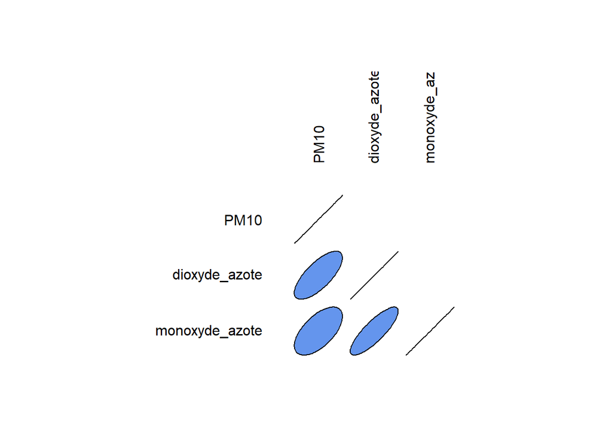

However, as Anscombe’s quartet shows, correlation is not sufficient to characterise relationships between variables. One needs to use plots.

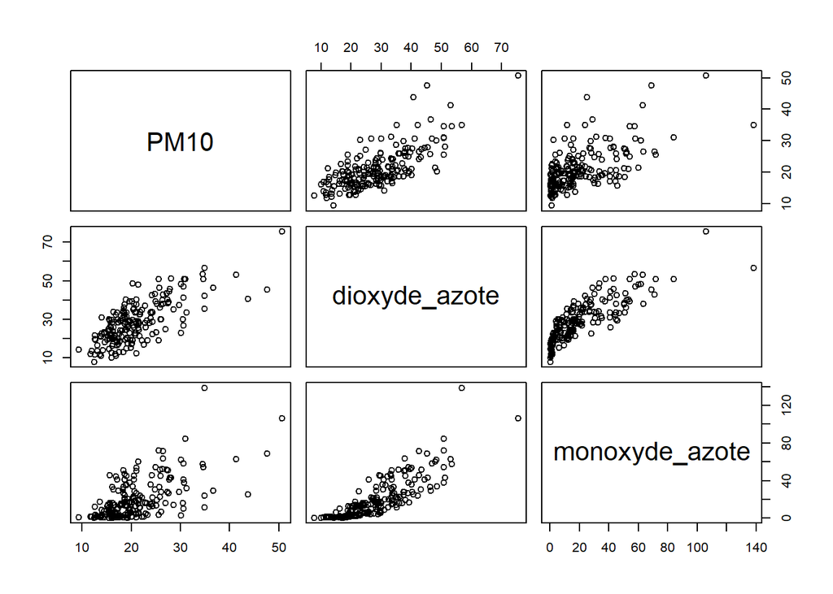

### Linear model

We can be satisfied that the relationships are linear, but there is a high degree of collinearity between our predictor variables NO and NO<sub>2</sub> (r = 0.83). We’ll fit the entire model and fix this later. We’re also interested in seeing if there’s a difference between the different cities, Lyon and Annecy.

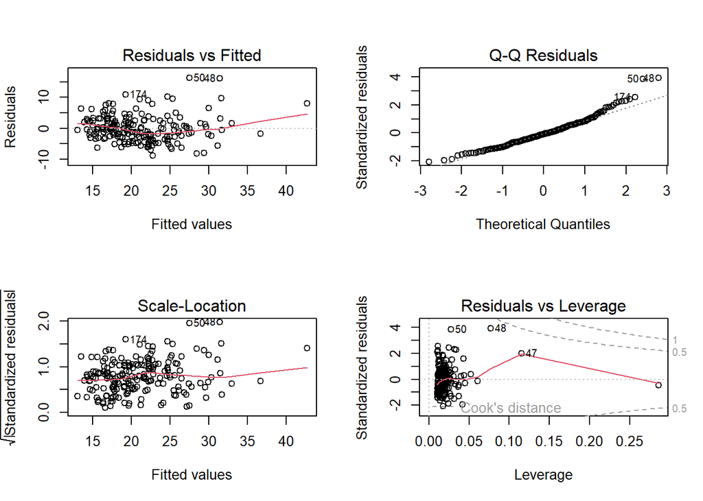

We don’t see an increase in spread with increasing magnitude nor do we see any vast deviations from normality. There are a number of values with high leverage however. Let’s try to isolate those. We can use `hatvalues` to isolate high leverage values.

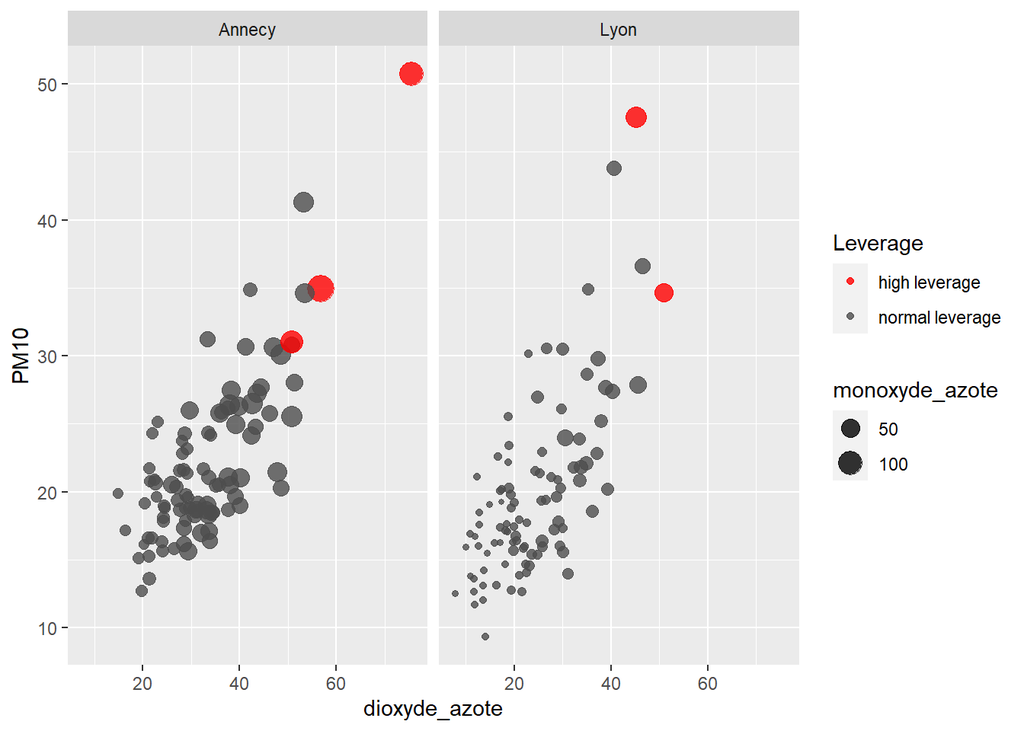

We have NO<sub>2</sub> on the x axis, NO on the size axis, PM10 on the y axis and high leverage values in red. We can definitely see the high influence these values have. It’s tempting to get rid of them, but they seem largely in line with the existing data. We also see something very interesting when we split these two cities apart. While they have similar values for NO<sub>2</sub> and PM10, there’s a very big difference. We theorize that this difference is due to burning of fuels for heating. This would also explain why the pollution spikes in winter. According to the US Environmental Protection Agency (EPA, https://www3.epa.gov/ttncatc1/dir1/fnoxdoc.pdf), NO emissions come principally from combustion and is largely anthropogenic. This is of no major concern however; unlike carbon monoxide, nitrogen monoxide isn’t very soluble in water and so only poses a threat to infants and other sensitive individuals.

```
Call:
lm(formula = PM10 ~ dioxyde_azote + monoxyde_azote + city, data = raw_airquality)

Residuals:
    Min      1Q  Median      3Q     Max
-8.8206 -2.7820 -0.4329  2.4393 16.2925

Coefficients:
               Estimate Std. Error t value Pr(>|t|)
(Intercept)     7.19906    1.21135   5.943 1.33e-08 ***
dioxyde_azote   0.40419    0.05160   7.833 3.39e-13 ***
monoxyde_azote  0.04693    0.02907   1.614 0.108112
cityLyon        2.66344    0.75206   3.542 0.000502 ***
---
Signif. codes:  0 '***' 0.001 '**' 0.01 '*' 0.05 '.' 0.1 ' ' 1

Residual standard error: 4.288 on 188 degrees of freedom
Multiple R-squared:  0.5593,    Adjusted R-squared:  0.5522
F-statistic: 79.52 on 3 and 188 DF,  p-value: < 2.2e-16
```

We see that City and NO<sub>2</sub> are good predictors, but what about the collinearity?

### Stepwise regression

We’ll use AIC as a criterion and progressively drop predictors from our model

```
Start:  AIC=563.01
PM10 ~ dioxyde_azote + monoxyde_azote + city

                 Df Sum of Sq    RSS    AIC
<none>                        3457.1 563.01
- monoxyde_azote  1     47.93 3505.1 563.66
- city            1    230.64 3687.8 573.41
- dioxyde_azote   1   1128.40 4585.5 615.25
```

```
Call:
lm(formula = PM10 ~ dioxyde_azote + monoxyde_azote + city, data = raw_airquality)

Coefficients:
   (Intercept)   dioxyde_azote  monoxyde_azote        cityLyon
       7.19906         0.40419         0.04693         2.66344
```

Automatic methods have failed us, performing the manual approach:

```
Call:
lm(formula = PM10 ~ dioxyde_azote + city, data = raw_airquality)

Residuals:
    Min      1Q  Median      3Q     Max
-9.2840 -2.7764 -0.3147  2.3918 17.5825

Coefficients:
              Estimate Std. Error t value Pr(>|t|)
(Intercept)    6.52419    1.14175   5.714 4.23e-08 ***
dioxyde_azote  0.47017    0.03162  14.868  < 2e-16 ***
cityLyon       2.16381    0.68834   3.144  0.00194 **
---
Signif. codes:  0 '***' 0.001 '**' 0.01 '*' 0.05 '.' 0.1 ' ' 1

Residual standard error: 4.306 on 189 degrees of freedom
Multiple R-squared:  0.5532,    Adjusted R-squared:  0.5484
F-statistic:   117 on 2 and 189 DF,  p-value: < 2.2e-16
```

The trimmed model has similar predictive power. The AIC of this model is 1110.53 whereas the original model had an AIC of 1109.89. We see that an increase in 1 µ/m^3 NO<sub>2</sub> results in a 0.47 µ/m^3 increase in PM10.

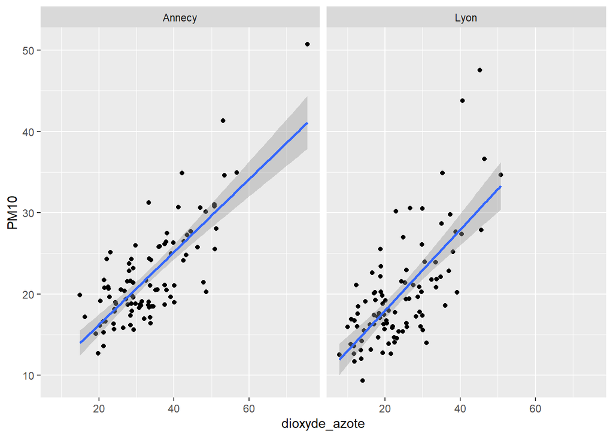

Blue line is model, gray area corresponds to Standard Error.

# Conclusions

- Annecy and Lyon differ in the NO pollutant levels, likely due to burning of fuel for heating
- We can predict PM10 levels by using NO<sub>2</sub> levels